# Variance structure

Timothee Bonnet

7 May 2020

```r
library(lmerTest)
```

```r
library(ggplot2)
```

**Take-home:**

- Not accounting for structure in the response variable can hide the true relationship between two variables
- Not accounting for structure in the response variable will make your models underestimate uncertainty.
- Use random effects to efficiently capture variation due to grouping factors and get better parameter estimates and more correct standard errors and p-values.

## Thorns and Simpson paradox

Imagine you have measured how much a plant species is attacked by big herbivores as a function of how many thorns the plant grows on stems. You have collected data in 5 locations and visualise the relationship between herbivory and quantity of thorns

```r
thorndata <- read.csv("data/thorndata.csv")
str(thorndata)
```

```
## 'data.frame':    100 obs. of  3 variables:
##  $ herbivory   : num  4.53 4.6 3.89 4.05 3.73 ...
##  $ thorndensity: num  1.72 1.75 2.2 2.3 2.43 ...
##  $ site        : Factor w/ 5 levels "a","b","c","d",..: 1 1 1 1 1 1 1 1 1 1 ...
```

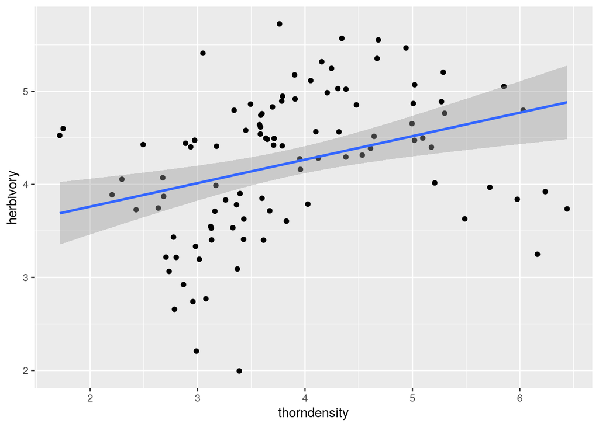

```r
ggplot(aes(x=thorndensity, y= herbivory), data = thorndata) +  geom_point()+
  geom_smooth(method = "lm")
```

```r
m0 <- lm(thorndensity ~ herbivory, data=thorndata)
summary(m0)
```

```
##
## Call:
## lm(formula = thorndensity ~ herbivory, data = thorndata)
##
## Residuals:
##     Min      1Q  Median      3Q     Max
## -2.2660 -0.4745 -0.2017  0.3563  2.8093
##
## Coefficients:
##             Estimate Std. Error t value Pr(>|t|)
## (Intercept)   1.9691     0.5428   3.628 0.000456 ***
## herbivory     0.4447     0.1264   3.520 0.000657 ***
## ---
## Signif. codes:  0 '***' 0.001 '**' 0.01 '*' 0.05 '.' 0.1 ' ' 1
##
## Residual standard error: 0.9627 on 98 degrees of freedom
## Multiple R-squared:  0.1122, Adjusted R-squared:  0.1032
## F-statistic: 12.39 on 1 and 98 DF,  p-value: 0.0006566
```

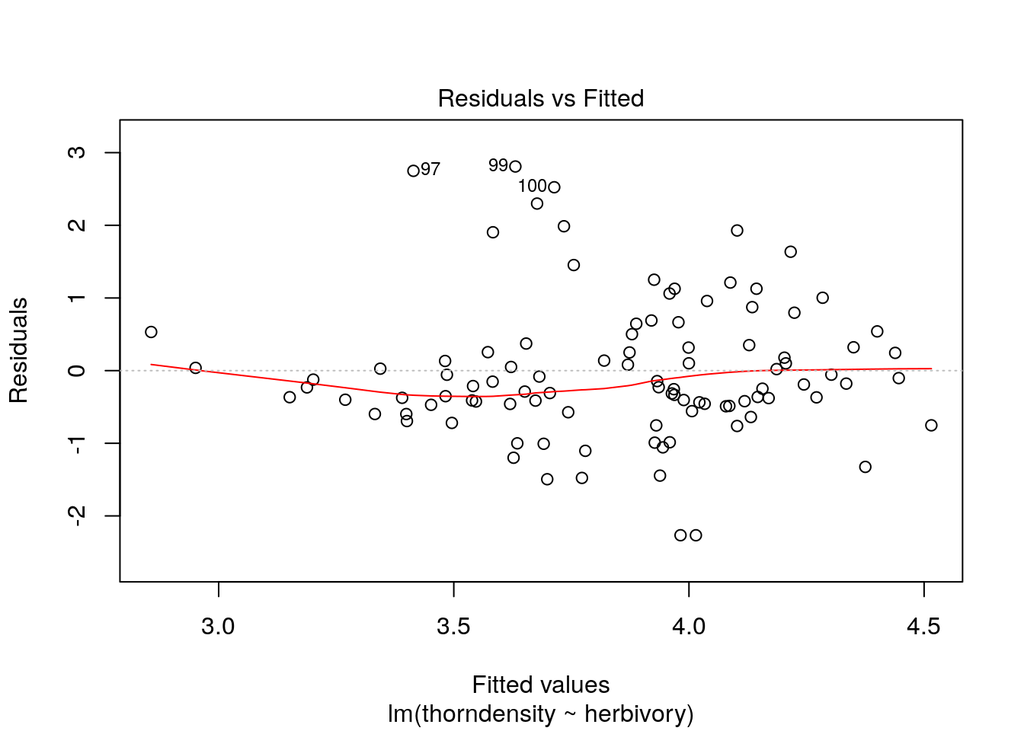

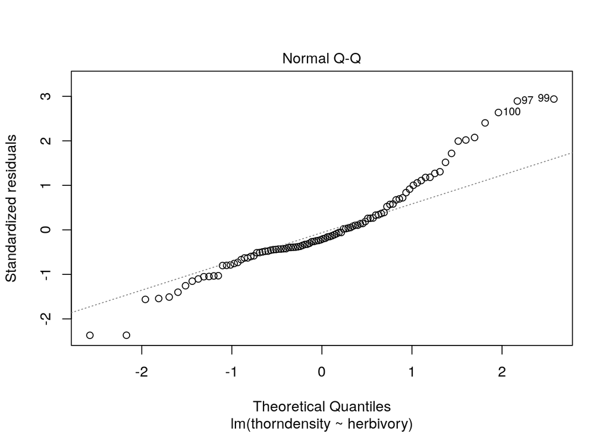

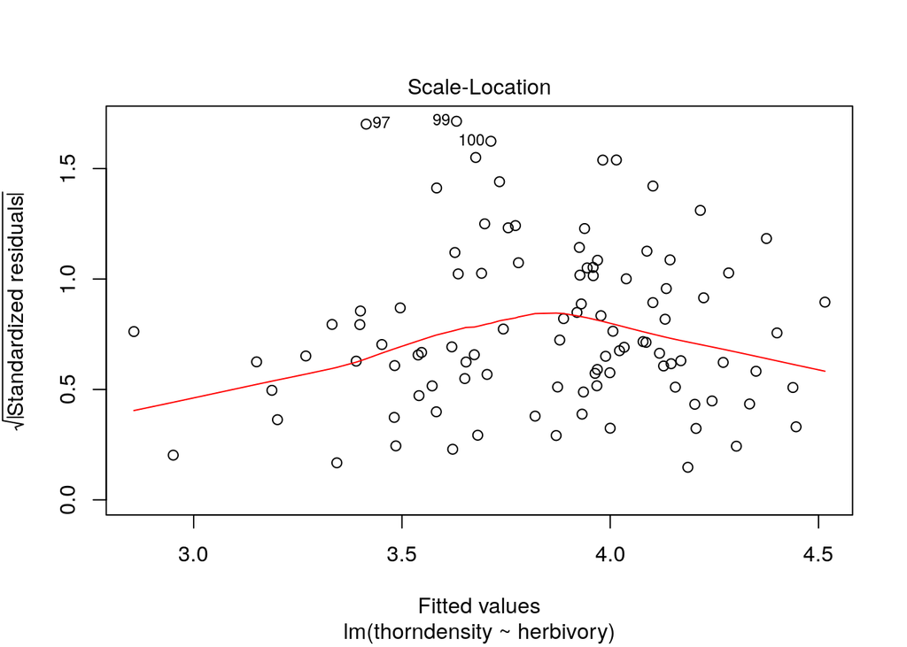

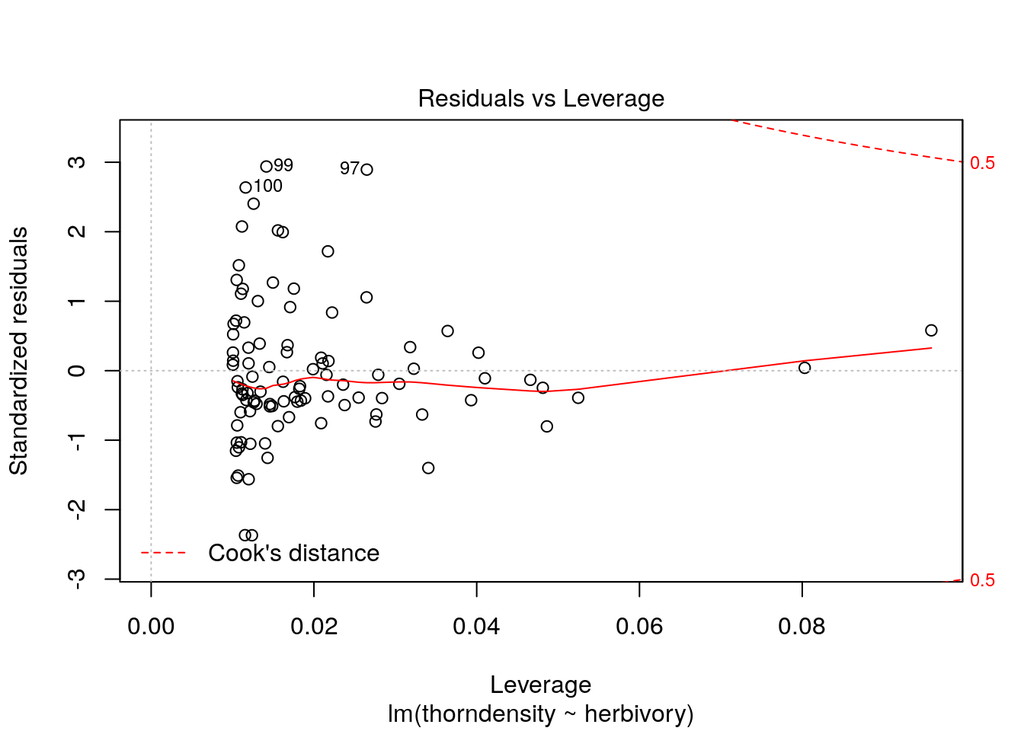

```r
plot(m0)
```

```r
library(performance)

check_model(m0)
```

```
## Not enough model terms in the conditional part of the model to check for multicollinearity.
```

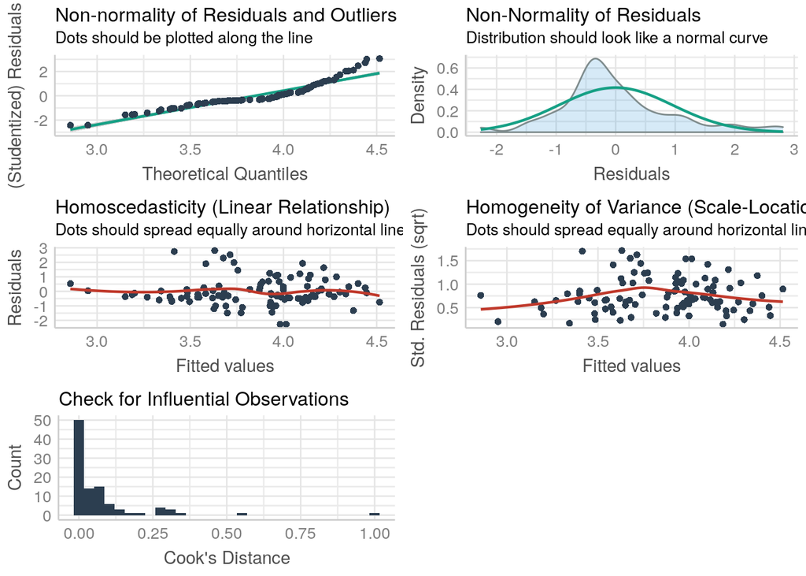

Model checks suggest some major unexplained structure in the data. It is likely due to site, which we have not included in our model.

Let’s visualize the data with colors related to site:

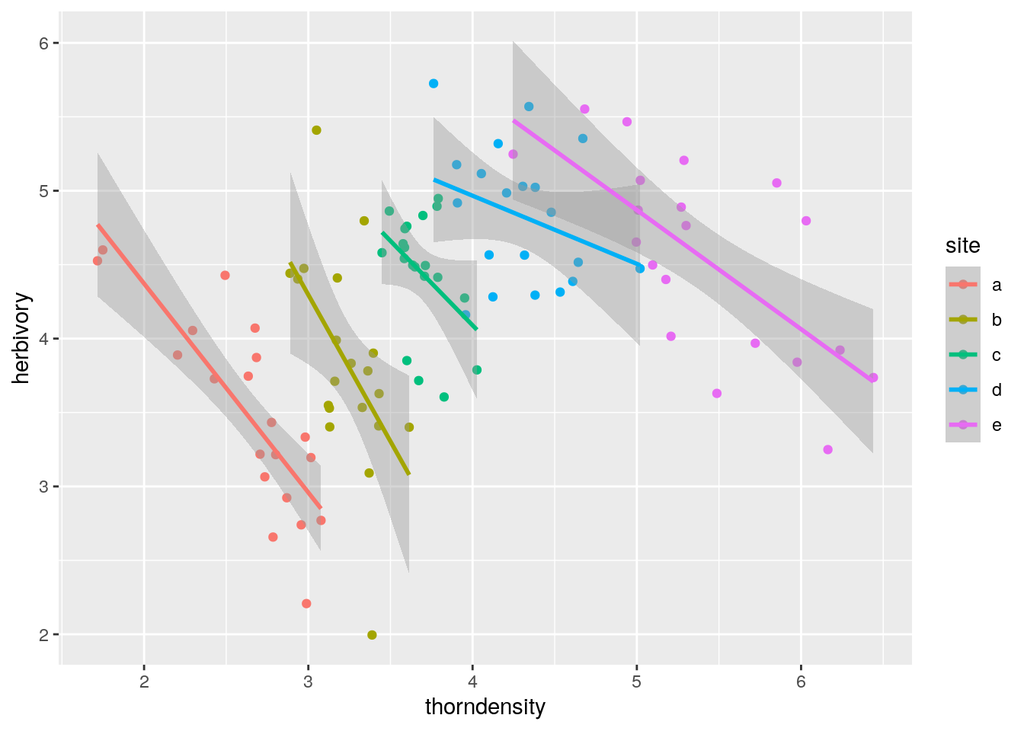

```r
ggplot(aes(x=thorndensity, y= herbivory, color=site), data = thorndata) +  geom_point()+
  geom_smooth(method = "lm")
```

Indeed, site is a major source of variation.

A model that account for site changes the direction of the effect of thorndensity:

```r
m1 <- lm( herbivory  ~thorndensity+ as.factor(site), data=thorndata)
summary(m1)
```

```
##
## Call:
## lm(formula = herbivory ~ thorndensity + as.factor(site), data = thorndata)
##
## Residuals:
##      Min       1Q   Median       3Q      Max
## -1.68769 -0.28889  0.04982  0.24924  1.39683
##
## Coefficients:
##                  Estimate Std. Error t value Pr(>|t|)
## (Intercept)        6.0471     0.3872  15.617  < 2e-16 ***
## thorndensity      -0.9752     0.1414  -6.899 6.02e-10 ***
## as.factor(site)b   0.9400     0.1762   5.334 6.62e-07 ***
## as.factor(site)c   1.9958     0.2147   9.295 5.80e-15 ***
## as.factor(site)d   2.9706     0.2812  10.562  < 2e-16 ***
## as.factor(site)e   3.7674     0.4219   8.929 3.48e-14 ***
## ---
## Signif. codes:  0 '***' 0.001 '**' 0.01 '*' 0.05 '.' 0.1 ' ' 1
##
## Residual standard error: 0.4875 on 94 degrees of freedom
## Multiple R-squared:  0.6151, Adjusted R-squared:  0.5947
## F-statistic: 30.05 on 5 and 94 DF,  p-value: < 2.2e-16
```

```r
anova(m1)
```

```
## Analysis of Variance Table
##
## Response: herbivory
##                 Df  Sum Sq Mean Sq F value    Pr(>F)
## thorndensity     1  6.5156  6.5156  27.412 9.992e-07 ***
## as.factor(site)  4 29.1932  7.2983  30.705 2.407e-16 ***
## Residuals       94 22.3426  0.2377
## ---
## Signif. codes:  0 '***' 0.001 '**' 0.01 '*' 0.05 '.' 0.1 ' ' 1
```

If we want to visualize what the model m1 predicts in ggplot, we need some more coding:

```r
predlm <- predict(m1, interval = "confidence")
datlm = cbind(thorndata, predlm)

predlm <- predict(m1, interval = "confidence")
datalm <- cbind(thorndata, predlm)
head(datalm)
```

```
##   herbivory thorndensity site      fit      lwr      upr
## 1  4.526133     1.716481    a 4.373192 4.037951 4.708433
## 2  4.599632     1.748753    a 4.341719 4.013343 4.670096
## 3  3.888889     2.203868    a 3.897880 3.650773 4.144988
## 4  4.054832     2.295535    a 3.808484 3.572708 4.044260
## 5  3.727945     2.427895    a 3.679403 3.455740 3.903066
## 6  3.745884     2.634347    a 3.478066 3.261607 3.694525
```

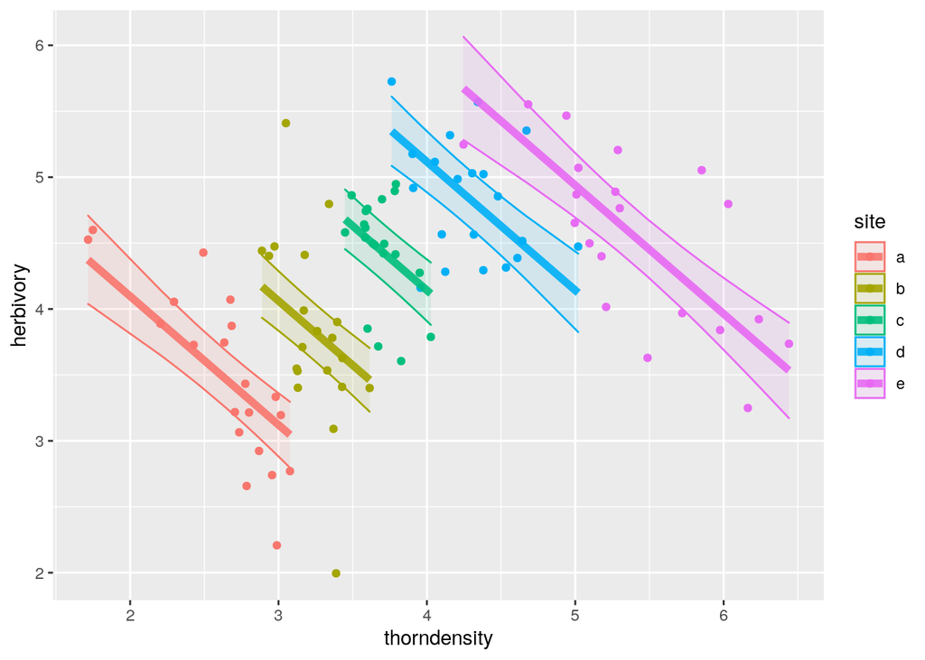

```r
ggplot(datalm, aes(x=thorndensity, y=herbivory, color=site)) +
  geom_point() + geom_line(aes(y=fit), size=2, alpha=0.9) +
  geom_ribbon(aes(ymin=lwr, ymax=upr, fill=site), alpha=0.1)
```

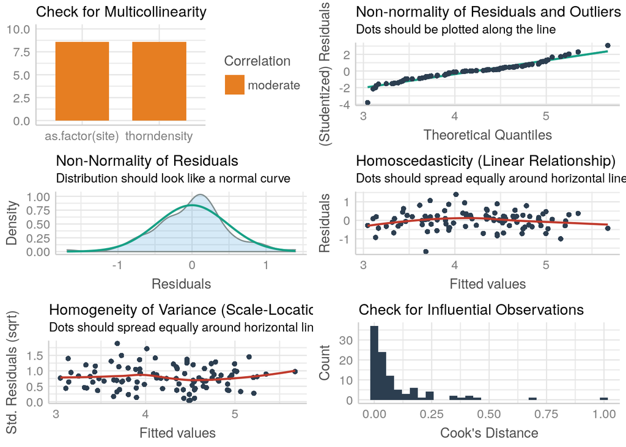

```r
check_model(m1)
```

The default model used by ggplot corresponds to a different question: does the relationship herbivory/thorndensity varies among sites?

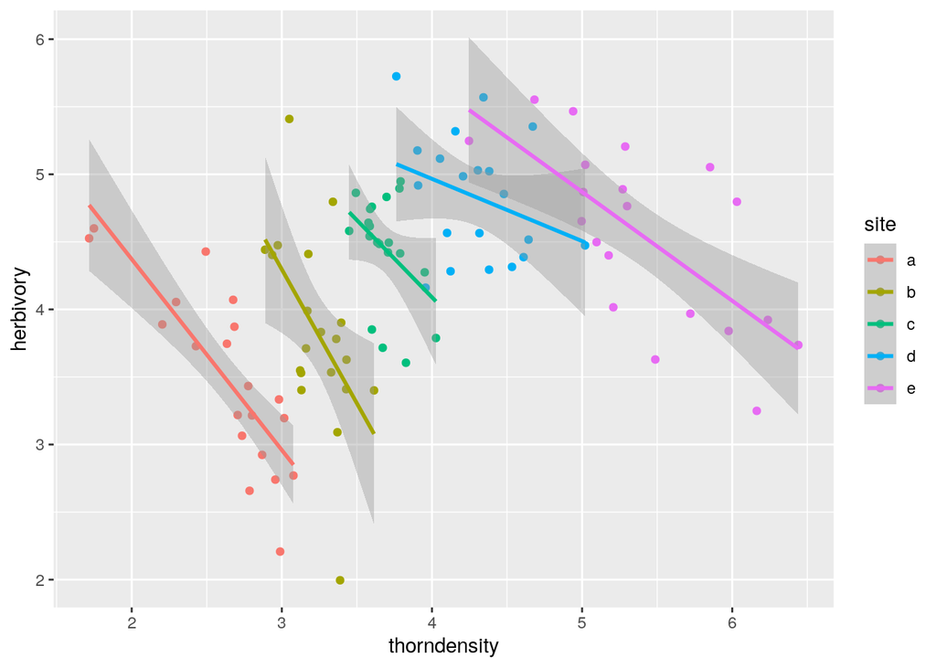

```r
ggplot(aes(x=thorndensity, y= herbivory, color=site), data = thorndata) +  geom_point()+
  geom_smooth(method = "lm")
```

```r
m2 <- lm(herbivory ~ thorndensity * as.factor(site), data=thorndata)
summary(m2)
```

```
##
## Call:
## lm(formula = herbivory ~ thorndensity * as.factor(site), data = thorndata)
##
## Residuals:
##      Min       1Q   Median       3Q      Max
## -1.53118 -0.26592  0.00189  0.22158  1.21267
##
## Coefficients:
##                               Estimate Std. Error t value Pr(>|t|)
## (Intercept)                     7.1978     0.7527   9.563 2.31e-15 ***
## thorndensity                   -1.4130     0.2835  -4.985 2.99e-06 ***
## as.factor(site)b                3.0457     2.0111   1.514   0.1334
## as.factor(site)c                1.4588     2.9031   0.503   0.6165
## as.factor(site)d               -0.3892     1.6854  -0.231   0.8179
## as.factor(site)e                1.7014     1.2876   1.321   0.1897
## thorndensity:as.factor(site)b  -0.5696     0.6419  -0.887   0.3773
## thorndensity:as.factor(site)c   0.2713     0.8113   0.334   0.7389
## thorndensity:as.factor(site)d   0.9524     0.4507   2.113   0.0374 *
## thorndensity:as.factor(site)e   0.6070     0.3425   1.772   0.0797 .
## ---
## Signif. codes:  0 '***' 0.001 '**' 0.01 '*' 0.05 '.' 0.1 ' ' 1
##
## Residual standard error: 0.4764 on 90 degrees of freedom
## Multiple R-squared:  0.6481, Adjusted R-squared:  0.6129
## F-statistic: 18.41 on 9 and 90 DF,  p-value: < 2.2e-16
```

```r
anova(m2)
```

```
## Analysis of Variance Table
##
## Response: herbivory
##                              Df  Sum Sq Mean Sq F value    Pr(>F)
## thorndensity                  1  6.5156  6.5156 28.7028 6.432e-07 ***
## as.factor(site)               4 29.1932  7.2983 32.1507 < 2.2e-16 ***
## thorndensity:as.factor(site)  4  1.9124  0.4781  2.1061   0.08653 .
## Residuals                    90 20.4302  0.2270
## ---
## Signif. codes:  0 '***' 0.001 '**' 0.01 '*' 0.05 '.' 0.1 ' ' 1
```

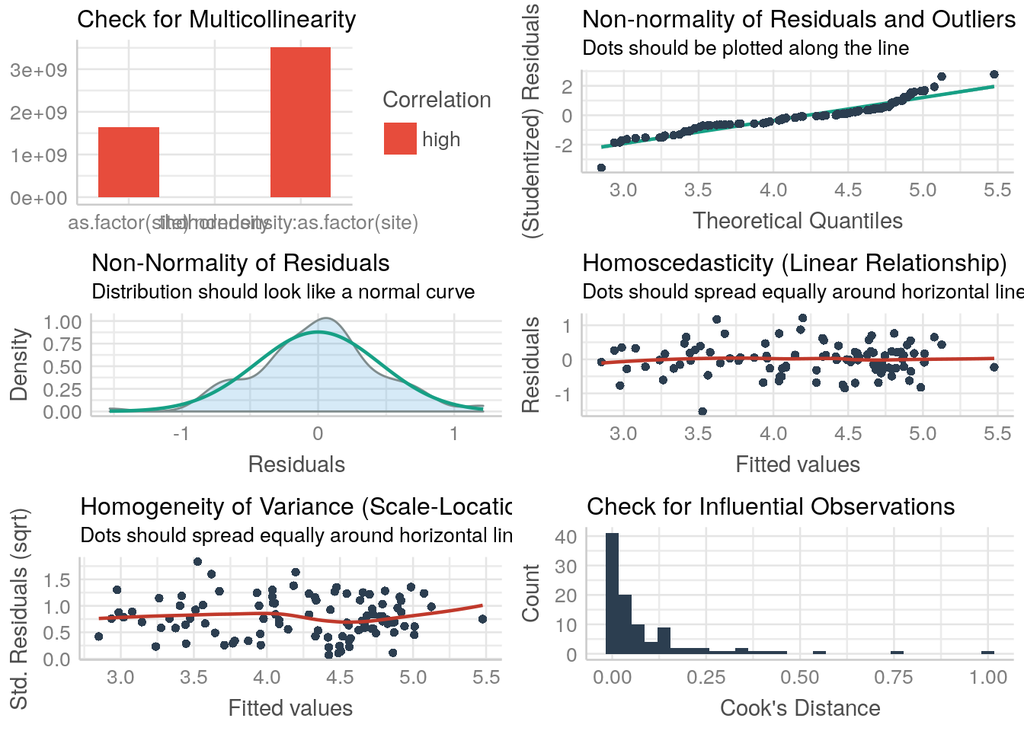

```r
check_model(m2)
```

It seems like there is some sign of variation in the effect of thorndensity among sites, but it is not clear. The model with interaction is not necessary if we just want to know what is the effect of thorndensity on herbivory on average. (so, m1 is better given our question.)

### Random effect re-fit

```r
library(lmerTest)
mm1 <- lmer(thorndensity ~ herbivory + (1|site), data=thorndata)
summary(mm1)
```

```
## Linear mixed model fit by REML. t-tests use Satterthwaite's method [
## lmerModLmerTest]
## Formula: thorndensity ~ herbivory + (1 | site)
##    Data: thorndata
##
## REML criterion at convergence: 67
##
## Scaled residuals:
##      Min       1Q   Median       3Q      Max
## -3.15700 -0.54602 -0.04339  0.54773  2.63404
##
## Random effects:
##  Groups   Name        Variance Std.Dev.
##  site     (Intercept) 1.48095  1.2169
##  Residual             0.08401  0.2899
## Number of obs: 100, groups:  site, 5
##
## Fixed effects:
##             Estimate Std. Error       df t value Pr(>|t|)
## (Intercept)  5.29049    0.58443  5.26551   9.052 0.000209 ***
## herbivory   -0.34085    0.04991 94.36965  -6.829 8.23e-10 ***
## ---
## Signif. codes:  0 '***' 0.001 '**' 0.01 '*' 0.05 '.' 0.1 ' ' 1
##
## Correlation of Fixed Effects:
##           (Intr)
## herbivory -0.361
```

Why random effect?

Fixed or random effect?

- First, if the predictor is a numerical variable (like size, temperature, number of species) you will generally want a fixed effect, because the order and distance between values is likely meaningful. A random effect consider values as random “names” for grouping levels.
- In general it does not change inference much. Random effects are slightly more efficient because the differences between grouping levels are assumed to come from a normal distribution, instead of being estimated independently from each other.
- A slightly lame but practical reason to use random effects: models output are cleaner with random effects because you get a single parameter estimate for a grouping variable modeled as a random effect, instead of a parameter estimate for each level of the grouping variable when modeled with a fixed effect.
- Using a random effect instead of a fixed effect shifts the focus from the effect of each grouping level to variation among grouping levels. What is more interesting to you?
- Often we use random effect to “correct” for some structure in the data that is not of interest. But random variance parameters can be of interest in themselves. For instance they can quantify genetic variation, individual repeatability, niche specialisationif a variance parameter is of interest then estimate it using a random effect.
- On the other hand, if you are very interested in how different a particular grouping level is from other levels, use fixed effects.
- Be careful with random effects if the number of grouping levels is small. You definitely need at least 3, probably at least 5, maybe at least 10With few grouping levels the fitting algorithm could have difficulties estimating the random variance, leading to unstable results (you may get different results from different algorithms) or the random variance being estimated to exactly zero.

## Drought data.

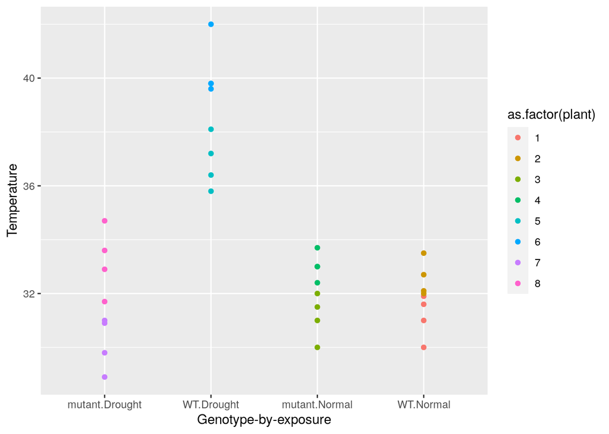

```r
drought_data <- read.csv("data/droughtdata.csv")

ggplot(drought_data, aes(x=interaction(Genotype, WaterCondition),
y=Temperature, color=as.factor(plant)))+ geom_point()+xlab("Genotype-by-exposure")
```

```r
mint <- lmer(Temperature ~ 1 + Genotype*WaterCondition + (1|plant), data = drought_data)

summary(mint)
```

```
## Linear mixed model fit by REML. t-tests use Satterthwaite's method [
## lmerModLmerTest]
## Formula: Temperature ~ 1 + Genotype * WaterCondition + (1 | plant)
##    Data: drought_data
##
## REML criterion at convergence: 95.1
##
## Scaled residuals:
##      Min       1Q   Median       3Q      Max
## -1.51698 -0.57122 -0.07203  0.71235  1.93025
##
## Random effects:
##  Groups   Name        Variance Std.Dev.
##  plant    (Intercept) 3.1420   1.7726
##  Residual             0.8815   0.9389
## Number of obs: 32, groups:  plant, 8
##
## Fixed effects:
##                                 Estimate Std. Error      df t value Pr(>|t|)
## (Intercept)                      31.6875     1.2966  4.0000  24.439 1.66e-05
## GenotypeWT                        6.9000     1.8337  4.0000   3.763   0.0197
## WaterConditionNormal              0.3875     1.8337  4.0000   0.211   0.8430
## GenotypeWT:WaterConditionNormal  -7.1250     2.5932  4.0000  -2.748   0.0515
##
## (Intercept)                     ***
## GenotypeWT                      *
## WaterConditionNormal
## GenotypeWT:WaterConditionNormal .
## ---
## Signif. codes:  0 '***' 0.001 '**' 0.01 '*' 0.05 '.' 0.1 ' ' 1
##
## Correlation of Fixed Effects:
##             (Intr) GntyWT WtrCnN
## GenotypeWT  -0.707
## WtrCndtnNrm -0.707  0.500
## GntypWT:WCN  0.500 -0.707 -0.707
```

```r
anova(mint)
```

```
## Type III Analysis of Variance Table with Satterthwaite's method
##                         Sum Sq Mean Sq NumDF DenDF F value  Pr(>F)
## Genotype                5.8402  5.8402     1     4  6.6257 0.06172 .
## WaterCondition          5.2854  5.2854     1     4  5.9962 0.07054 .
## Genotype:WaterCondition 6.6542  6.6542     1     4  7.5491 0.05150 .
## ---
## Signif. codes:  0 '***' 0.001 '**' 0.01 '*' 0.05 '.' 0.1 ' ' 1
```

## Practice: Random effect and interaction with one continuous variables

Last time we saw there was clear interaction Age-by-Sex for Escape distance in the kangaroo data set.

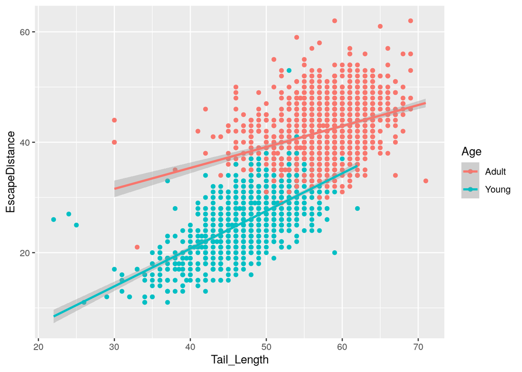

```r
roo <- read.csv("data/roo.csv")
ggplot(roo, aes(x=Tail_Length, y=EscapeDistance, color=Age)) +
  geom_point() + geom_smooth(method = "lm")
```

```r
summary(lm(EscapeDistance ~ Age*Sex, data = roo))
```

```
##
## Call:
## lm(formula = EscapeDistance ~ Age * Sex, data = roo)
##
## Residuals:
##      Min       1Q   Median       3Q      Max
## -23.4427  -3.4427  -0.2214   3.5573  27.1196
##
## Coefficients:
##                  Estimate Std. Error t value Pr(>|t|)
## (Intercept)       40.2214     0.1777 226.367   <2e-16 ***
## AgeYoung         -14.8257     0.2977 -49.808   <2e-16 ***
## SexMale            4.2213     0.2782  15.174   <2e-16 ***
## AgeYoung:SexMale  -3.7366     0.4278  -8.735   <2e-16 ***
## ---
## Signif. codes:  0 '***' 0.001 '**' 0.01 '*' 0.05 '.' 0.1 ' ' 1
##
## Residual standard error: 5.177 on 2452 degrees of freedom
## Multiple R-squared:  0.7145, Adjusted R-squared:  0.7142
## F-statistic:  2046 on 3 and 2452 DF,  p-value: < 2.2e-16
```

However, all data points were not collected independently of each others. We measured individuals multiple times and we repeated the experiment on multiple years.

Transform this model into a mixed model with id and year as random effects. Does that change the parameter estimates and Std. Error?

```r
m1 <- lmer(EscapeDistance ~ Sex*Age + (1|id) + (1|Year), data = roo)
summary(m1)
```

```
## Linear mixed model fit by REML. t-tests use Satterthwaite's method [
## lmerModLmerTest]
## Formula: EscapeDistance ~ Sex * Age + (1 | id) + (1 | Year)
##    Data: roo
##
## REML criterion at convergence: 14572
##
## Scaled residuals:
##     Min      1Q  Median      3Q     Max
## -3.7235 -0.5637 -0.0198  0.5645  6.5002
##
## Random effects:
##  Groups   Name        Variance Std.Dev.
##  id       (Intercept) 10.7936  3.2854
##  Year     (Intercept)  0.8944  0.9457
##  Residual             16.0825  4.0103
## Number of obs: 2456, groups:  id, 818; Year, 8
##
## Fixed effects:
##                   Estimate Std. Error        df t value Pr(>|t|)
## (Intercept)        39.7782     0.4295   14.4181  92.609  < 2e-16 ***
## SexMale             3.7820     0.4028  923.2886   9.390  < 2e-16 ***
## AgeYoung          -14.8392     0.3098 2303.3270 -47.894  < 2e-16 ***
## SexMale:AgeYoung   -2.9305     0.4576 2257.7653  -6.404 1.84e-10 ***
## ---
## Signif. codes:  0 '***' 0.001 '**' 0.01 '*' 0.05 '.' 0.1 ' ' 1
##
## Correlation of Fixed Effects:
##             (Intr) SexMal AgeYng
## SexMale     -0.406
## AgeYoung    -0.350  0.359
## SexMl:AgYng  0.237 -0.643 -0.647
```

```r
anova(m1)
```

```
## Type III Analysis of Variance Table with Satterthwaite's method
##         Sum Sq Mean Sq NumDF   DenDF  F value    Pr(>F)
## Sex        899     899     1  660.73   55.911 2.420e-13 ***
## Age      75583   75583     1 1940.15 4699.689 < 2.2e-16 ***
## Sex:Age    660     660     1 2257.77   41.012 1.835e-10 ***
## ---
## Signif. codes:  0 '***' 0.001 '**' 0.01 '*' 0.05 '.' 0.1 ' ' 1
```

The results do not change dramatically, but parameters estimate change a bit and the uncertainty in the parameter estimates increases (larger standard errors and p-values).